# Linear Regressions

Congxin (David) Xu

1/5/2021

## Description

This tutorial is going to discuss how to implement linear regressions in `R`. We are going to cover:

- Ordinary Least Squares Regression
- Step-wise Regression
- Penalized Linear Regression
  - Lasso Regression
  - Ridge Regression
  - Elastic Net Regression

## Package Dependency

- [`tidyverse`](https://www.tidyverse.org/)
  - We will mainly use `tidyverse` for data manipulation (`dplyr`) and visualization (`ggplot2`).
- [`broom`](https://cran.r-project.org/web/packages/broom/broom.pdf)
  - We will mainly use the ‘tidy()’ function from broom to print out the cleaned summary of the model information.
- [`stats`](https://stat.ethz.ch/R-manual/R-devel/library/stats/html/00Index.html)
  - `stats` package is part of the base R package, so you do not need to install it. It should already be pre-installed.
  - This is the package that contains the `lm()` function that will perform the linear regression and the `step()` function that will perform the stepwise regression.
- [`glmnet`](https://cran.r-project.org/web/packages/glmnet/glmnet.pdf)
  - Title: Lasso and Elastic-Net Regularized Generalized Linear Models
  - This is the package that contains the functions that will perform ridge, lasso, and elastic net regressions.

## Use Case

- Linear Regression models assume the linear relationship between the response variable and the predictors. It can be used to solve almost all regression type of problems.

## Caution

- If you care more about the inference of the model or the interpretation of the model, you need to pay attention to the potential violation of the assumptions of linear regression models.
- If you care more about the predictive power of the model, you need to pay attention to the accuracy of the model.

## Tutorial

Load the required library

```r
library(tidyverse)
library(broom)
library(glmnet)
```

The data we will use is the housing price data from [Kaggle](https://www.kaggle.com/c/house-prices-advanced-regression-techniques).

- Response Variable: **`price`**

**Read and Preview the Training Data**

```r
train <- read_csv('.\\Data\\realestate-train.csv')
head(train)
```

```
#> # A tibble: 6 x 13
#>   price PoolArea GarageCars Fireplaces TotRmsAbvGrd Baths SqFeet CentralAir
#>   <dbl>    <dbl>      <dbl>      <dbl>        <dbl> <dbl>  <dbl> <chr>
#> 1  208.        0          2          0            8     3   1710 Y
#> 2  140         0          3          1            7     1   1717 Y
#> 3  250         0          3          1            9     3   2198 Y
#> 4  143         0          2          0            5     2   1362 Y
#> 5  307         0          2          1            7     2   1694 Y
#> 6  130.        0          2          2            8     2   1774 Y
#> # ... with 5 more variables: Age <dbl>, LotSize <dbl>, BldgType <chr>,
#> #   HouseStyle <chr>, condition <dbl>
```

**Read and Preview the Testing Data**

```r
test <- read_csv('.\\Data\\realestate-test.csv')
head(test)
```

```
#> # A tibble: 6 x 12
#>   PoolArea GarageCars Fireplaces TotRmsAbvGrd Baths SqFeet CentralAir   Age
#>      <dbl>      <dbl>      <dbl>        <dbl> <dbl>  <dbl> <chr>      <dbl>
#> 1        0          2          0            6     2   1516 Y             45
#> 2        0          1          0            4     1    616 Y             85
#> 3        0          1          1            8     2   1696 Y             45
#> 4        0          2          0            6     3   1479 Y             34
#> 5        0          2          1            8     2   2217 Y             37
#> 6        0          2          1            7     4   1868 Y             23
#> # ... with 4 more variables: LotSize <dbl>, BldgType <chr>, HouseStyle <chr>,
#> #   condition <dbl>
```

### Ordinary Least Squares Regression

**Assumptions**

1. The errors, for each fixed value of $x$, have mean 0.
2. The errors, for each fixed value of $x$, have constant variance.
3. The errors are independent.
4. The errors, for each fixed value of $x$, follow a normal distribution.

**For this section, we will just focus on the following predictors:**

- `SqFeet`: *numeric*
- `Age`: *numeric*
- `Baths`: *numeric*
- `TotRmsAbvGrd`: *numeric*
- `BldgType`: *categorical*

**Set Up the Model**

```r
linear_model <- lm(data = train, price ~ SqFeet + Age + Baths + TotRmsAbvGrd + BldgType)
summary(linear_model)
```

```
#>
#> Call:
#> lm(formula = price ~ SqFeet + Age + Baths + TotRmsAbvGrd + BldgType,
#>     data = train)
#>
#> Residuals:
#>     Min      1Q  Median      3Q     Max
#> -397.09  -22.86   -3.89   17.17  306.17
#>
#> Coefficients:
#>                  Estimate Std. Error t value Pr(>|t|)
#> (Intercept)     88.849827   6.685101  13.291  < 2e-16 ***
#> SqFeet           0.125998   0.005174  24.351  < 2e-16 ***
#> Age             -1.193016   0.052919 -22.544  < 2e-16 ***
#> Baths          -16.147409   2.676063  -6.034 2.15e-09 ***
#> TotRmsAbvGrd    -2.871554   1.543678  -1.860   0.0631 .
#> BldgType2fmCon -13.884139   9.115507  -1.523   0.1280
#> BldgTypeDuplex -48.503128   7.255906  -6.685 3.60e-11 ***
#> BldgTypeTwnhs  -34.415303   7.437892  -4.627 4.13e-06 ***
#> BldgTypeTwnhsE -10.475239   5.043338  -2.077   0.0380 *
#> ---
#> Signif. codes:  0 '***' 0.001 '**' 0.01 '*' 0.05 '.' 0.1 ' ' 1
#>
#> Residual standard error: 43.62 on 1151 degrees of freedom
#> Multiple R-squared:  0.7098, Adjusted R-squared:  0.7078
#> F-statistic: 351.8 on 8 and 1151 DF,  p-value: < 2.2e-16
```

**Report Mean Squared Error on Training Data**

```r
mean((linear_model$residuals)^2)
```

```
#> [1] 1887.568
```

### Stepwise Regression Model

- For the stepwise regression model, we are going to try to include all predictors in the training data and see what parameters will be picked out based on the AIC.

```r
stepwise_model <- step(lm(data = train, price ~ .),
                     direction="both")
```

```
#> Start:  AIC=8518.43
#> price ~ PoolArea + GarageCars + Fireplaces + TotRmsAbvGrd + Baths +
#>     SqFeet + CentralAir + Age + LotSize + BldgType + HouseStyle +
#>     condition
#>
#>                Df Sum of Sq     RSS    AIC
#> - TotRmsAbvGrd  1       128 1726824 8516.5
#> - Baths         1       902 1727598 8517.0
#> - PoolArea      1      2120 1728816 8517.9
#> <none>                      1726696 8518.4
#> - CentralAir    1      6354 1733050 8520.7
#> - Fireplaces    1     19735 1746431 8529.6
#> - LotSize       1     20036 1746732 8529.8
#> - GarageCars    1     71531 1798227 8563.5
#> - BldgType      4     84737 1811433 8566.0
#> - condition     1    116700 1843396 8592.3
#> - HouseStyle    7    138359 1865055 8593.8
#> - Age           1    315977 2042673 8711.4
#> - SqFeet        1    678470 2405166 8900.9
#>
#> Step:  AIC=8516.52
#> price ~ PoolArea + GarageCars + Fireplaces + Baths + SqFeet +
#>     CentralAir + Age + LotSize + BldgType + HouseStyle + condition
#>
#>                Df Sum of Sq     RSS    AIC
#> - Baths         1       932 1727756 8515.1
#> - PoolArea      1      2193 1729017 8516.0
#> <none>                      1726824 8516.5
#> + TotRmsAbvGrd  1       128 1726696 8518.4
#> - CentralAir    1      6404 1733228 8518.8
#> - Fireplaces    1     19761 1746585 8527.7
#> - LotSize       1     20398 1747221 8528.1
#> - GarageCars    1     71448 1798272 8561.5
#> - BldgType      4     88501 1815325 8566.5
#> - condition     1    116956 1843780 8590.5
#> - HouseStyle    7    142317 1869141 8594.4
#> - Age           1    317434 2044257 8710.3
#> - SqFeet        1   1037513 2764337 9060.3
#>
#> Step:  AIC=8515.14
```

[output cut: 21 more lines]

```
#>
#>                Df Sum of Sq     RSS    AIC
#> <none>                      1730040 8514.7
#> + PoolArea      1      2284 1727756 8515.1
#> + Baths         1      1023 1729017 8516.0
#> + TotRmsAbvGrd  1       242 1729798 8516.5
#> - CentralAir    1      6211 1736251 8516.8
#> - Fireplaces    1     19398 1749438 8525.6
#> - LotSize       1     20602 1750642 8526.4
#> - GarageCars    1     70025 1800065 8558.7
#> - BldgType      4     92293 1822333 8567.0
#> - condition     1    116180 1846220 8588.1
#> - HouseStyle    7    198750 1928790 8626.8
#> - Age           1    372627 2102667 8738.9
#> - SqFeet        1   1290972 3021012 9159.3
```

*Report the final parameters of stepwise model*

```r
summary(stepwise_model)
```

```
#>
#> Call:
#> lm(formula = price ~ GarageCars + Fireplaces + SqFeet + CentralAir +
#>     Age + LotSize + BldgType + HouseStyle + condition, data = train)
#>
#> Residuals:
#>     Min      1Q  Median      3Q     Max
#> -384.65  -20.16   -3.37   15.41  264.36
#>
#> Coefficients:
#>                    Estimate Std. Error t value Pr(>|t|)
#> (Intercept)      -3.729e+01  1.060e+01  -3.520 0.000449 ***
#> GarageCars        1.449e+01  2.133e+00   6.796 1.73e-11 ***
#> Fireplaces        7.739e+00  2.164e+00   3.577 0.000362 ***
#> SqFeet            1.090e-01  3.736e-03  29.179  < 2e-16 ***
#> CentralAirY      -1.164e+01  5.752e+00  -2.024 0.043212 *
#> Age              -9.298e-01  5.931e-02 -15.677  < 2e-16 ***
#> LotSize           4.291e-04  1.164e-04   3.686 0.000238 ***
#> BldgType2fmCon   -1.086e+01  8.414e+00  -1.291 0.196937
#> BldgTypeDuplex   -5.133e+01  6.730e+00  -7.626 5.07e-14 ***
#> BldgTypeTwnhs    -1.094e+01  6.838e+00  -1.600 0.109919
#> BldgTypeTwnhsE   -1.507e+00  4.449e+00  -0.339 0.734914
#> HouseStyle1.5Unf  4.174e+01  1.164e+01   3.588 0.000348 ***
#> HouseStyle1Story  2.325e+01  4.507e+00   5.159 2.93e-07 ***
#> HouseStyle2.5Fin -5.096e+01  1.597e+01  -3.191 0.001455 **
#> HouseStyle2.5Unf -1.267e+01  1.462e+01  -0.867 0.386262
#> HouseStyle2Story -1.156e+01  4.613e+00  -2.507 0.012331 *
#> HouseStyleSFoyer  3.649e+01  8.730e+00   4.180 3.14e-05 ***
#> HouseStyleSLvl    3.687e+00  6.854e+00   0.538 0.590733
#> condition         1.033e+01  1.181e+00   8.753  < 2e-16 ***
#> ---
#> Signif. codes:  0 '***' 0.001 '**' 0.01 '*' 0.05 '.' 0.1 ' ' 1
#>
#> Residual standard error: 38.94 on 1141 degrees of freedom
#> Multiple R-squared:  0.7707, Adjusted R-squared:  0.7671
#> F-statistic:   213 on 18 and 1141 DF,  p-value: < 2.2e-16
```

**Report Mean Squared Error on Training Data**

```r
mean((stepwise_model$residuals)^2)
```

```
#> [1] 1491.414
```

### Penalized Linear Regression

- $\lambda$ is the penalty on including additional variables to the model.
- We will first use `cv.glmnet()` function to determine the best penalty for this model using cross validation.

#### Lasso Regression

- **Lasso tends to shrink the coefficient of the predictors all the way to 0**.
- For the Lasso Regression, we need to set **`alpha = 1`**.

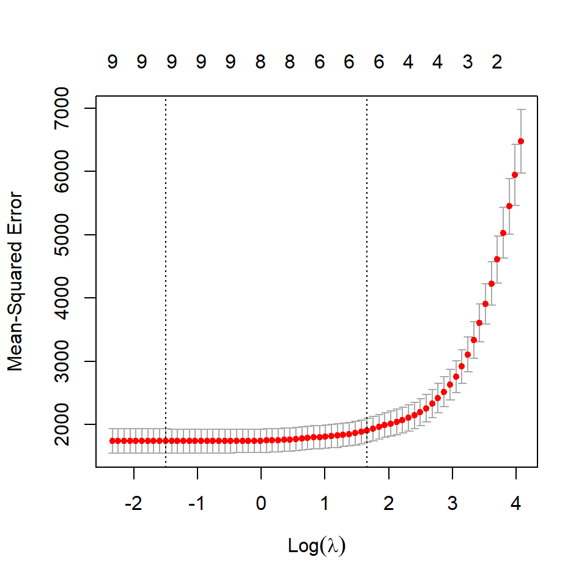

```r
# Control Randomness
set.seed(666)

# Initiate the Cross Validation
lasso_cv_model <- cv.glmnet(x = train %>%
                              select(-price,-CentralAir,-BldgType,-HouseStyle) %>%
                              as.matrix(),
                            y = train %>% select(price) %>% as.matrix(),
                            alpha = 1, # Lasso
                            nfolds = 10, # 10 fold cross validation
                            family = 'gaussian') # use "gaussian" or "poisson" for regression problems

# Visualize the Lasso Model with Cross Validation
plot(lasso_cv_model)
```

```r
# Report the Cross Validation MSE at lambda.1se
print(lasso_cv_model$cvm[which(lasso_cv_model$lambda == lasso_cv_model$lambda.1se)])
```

```
#> [1] 1904.202
```

- Then, we will use the $\lambda$ at 1 standard deviation (the 2nd dotted line above) as an input to the final `glmnet()` model.

```r
# Training the final lasso model for prediction
lasso_model <- glmnet(x = train %>%
                        select(-price,-CentralAir,-BldgType,-HouseStyle) %>%
                        as.matrix(),
                      y = train %>% select(price) %>% as.matrix(),
                      alpha = 1,
                      lambda = lasso_cv_model$lambda.1se, # lambda.1se is obtained from previous step
                      family = 'gaussian')

# Display the coefficients
print(lasso_model$beta)
```

```
#> 9 x 1 sparse Matrix of class "dgCMatrix"
#>                         s0
#> PoolArea      .
#> GarageCars   17.5969283585
#> Fireplaces   11.1080383319
#> TotRmsAbvGrd  .
#> Baths         .
#> SqFeet        0.0777654825
#> Age          -0.6951009174
#> LotSize       0.0002131176
#> condition     2.2415134889
```

Based on the output above, we can see that `PoolArea`, `TotRmsAbvGrd` and `Baths` are removed as unhelpful predictors.

#### Ridge Regression

- **Ridge tends to keep all the predictors.**.
- For the Ridge Regression, we need to set **`alpha = 0`**.

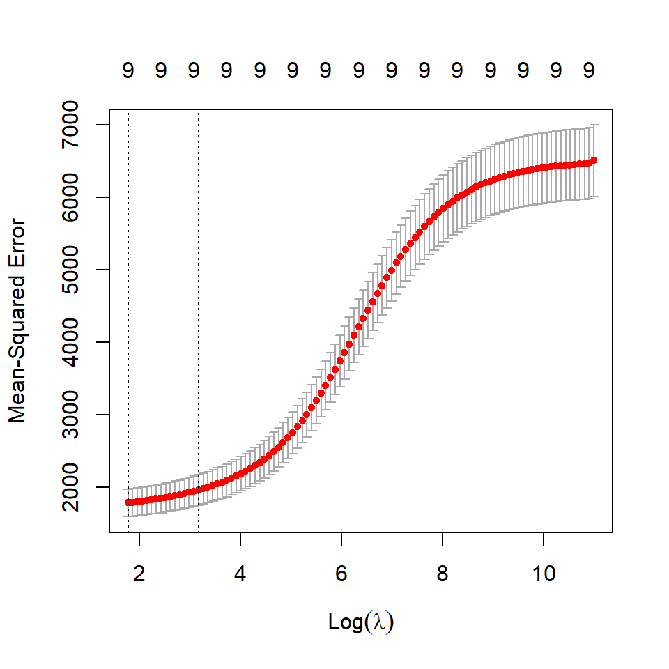

```r
# Control Randomness
set.seed(666)

# Initiate the Cross Validation
ridge_cv_model <- cv.glmnet(x = train %>%
                              select(-price,-CentralAir,-BldgType,-HouseStyle) %>%
                              as.matrix(),
                            y = train %>% select(price) %>% as.matrix(),
                            alpha = 0, # Ridge
                            nfolds = 10, # 10 fold cross validation
                            family = 'gaussian') # use "gaussian" or "poisson" for regression problems

# Visualize the Lasso Model with Cross Validation
plot(ridge_cv_model)
```

```r
# Report the Cross Validation MSE at lambda.1se
print(ridge_cv_model$cvm[which(ridge_cv_model$lambda == ridge_cv_model$lambda.1se)])
```

```
#> [1] 1961.971
```

```r
# Training the final lasso model for prediction
ridge_model <- glmnet(x = train %>%
                        select(-price,-CentralAir,-BldgType,-HouseStyle) %>%
                        as.matrix(),
                      y = train %>% select(price) %>% as.matrix(),
                      alpha = 0,
                      lambda = lasso_cv_model$lambda.1se, # lambda.1se is obtained from previous step
                      family = 'gaussian')

# Display the coefficients
print(ridge_model$beta)
```

```
#> 9 x 1 sparse Matrix of class "dgCMatrix"
#>                         s0
#> PoolArea      0.0536468543
#> GarageCars   20.1909524332
#> Fireplaces   15.1730775110
#> TotRmsAbvGrd  0.6570560932
#> Baths        -6.0528775518
#> SqFeet        0.0796526880
#> Age          -0.9203902779
#> LotSize       0.0005696545
#> condition     8.5942427331
```

Based on the output above, we can see that all predictors have non-zero coefficients in this Ridge model.

#### Elastic Net Regression

- For Elastic Net, we have 2 tuning parameters `alpha` and `lambda`.
- We need to find the best `alpha` value using a for loop with cross validation.
- Then, we need to find the best lambda based on the best alpha value.

```r
# Control Randomness
set.seed(666)

# Pre-defined setting
alpha <- seq(0, 1, 0.01)

# Create a empty list to store results
output <- list()

# Finding the best alpha
for (a in 1:length(alpha)) {

    # Build model using CV
  model <- cv.glmnet(x = train %>%
                       select(-price, -CentralAir, -BldgType, -HouseStyle) %>%
                       as.matrix(),
                     y = train %>% select(price) %>% as.matrix(),
                     nfolds = 10,
                     alpha = alpha[a],
                     family = 'gaussian')

    # Store the data into output
    output[[a]] <- data.frame(alpha = alpha[a],
                              lambda = model$lambda.1se,
                              # cvm is an output stored within the model object
                              # it is the cross validation mean squared error
                              mse = model$cvm[which(model$lambda == model$lambda.1se)])

}

# Convert list back to data frame
output <- bind_rows(output)

# Report alpha and lambda for final prediction
output %>%
  filter(mse == min(mse))
```

```
#>   alpha   lambda      mse
#> 1  0.67 5.417888 1856.318
```

```r
# Collect the best output
best <- output %>% filter(mse == min(mse))

# Training the final lasso model for prediction
elastic_net_model <- glmnet(x = train %>%
                              select(-price, -CentralAir, -BldgType, -HouseStyle) %>%
                              as.matrix(),
                            y = train %>% select(price) %>% as.matrix(),
                            alpha = best$alpha,
                            lambda = best$lambda, # obtained from the table above
                            family = 'gaussian')

# Display the coefficients
print(elastic_net_model$beta)
```

```
#> 9 x 1 sparse Matrix of class "dgCMatrix"
#>                         s0
#> PoolArea      .
#> GarageCars   18.4142472026
#> Fireplaces   12.5455570489
#> TotRmsAbvGrd  .
#> Baths         .
#> SqFeet        0.0769161325
#> Age          -0.7497810534
#> LotSize       0.0003373722
#> condition     4.3101717643
```

Based on the output above, we can see that `PoolArea`, `TotRmsAbvGrd` and `Baths` are removed as unhelpful predictors.

### Making Predictions

In this section, we are going to predict `price` on the test data using all 5 models generated above.

```r
test <- test %>%
  mutate(
    # Predict the future using linear regression
    price_linear_pred = predict(linear_model, newdata = test),

    # Predict the future using stepwise regression
    price_step_pred = predict(stepwise_model, newdata = test),

    # Predict the future using lasso regression
    price_lasso_pred = predict(
      lasso_model,
      newx = test %>%
        select(-CentralAir,-BldgType,-HouseStyle) %>%
        as.matrix()
    ),

    # Predict the future using ridge regression
    price_ridge_pred = predict(
      ridge_model,
      newx = test %>%
        select(-CentralAir,-BldgType,-HouseStyle) %>%
        as.matrix()
    ),

    # Predict the future using elastic net regression
    price_enet_pred = predict(
      elastic_net_model,
      newx = test %>%
        select(-CentralAir,-BldgType,-HouseStyle) %>%
        as.matrix()
    )
  )
```